# Practical Machine Learning - Course Project

KS

November 22, 2015

## Backgroud

Using devices such as Jawbone Up, Nike FuelBand, and Fitbit it is now possible to collect a large amount of data about personal activity relatively inexpensively. These type of devices are part of the quantified self movement - a group of enthusiasts who take measurements about themselves regularly to improve their health, to find patterns in their behavior, or because they are tech geeks. One thing that people regularly do is quantify how much of a particular activity they do, but they rarely quantify how well they do it. In this project, data from accelerometers on the belt, forearm, arm, and dumbell of 6 participants are used. Participants were asked to perform one set of 10 repetitions of the Unilateral Dumbbell Biceps Curl in five different fashions: exactly according to the specification (Class A), throwing the elbows to the front (Class B), lifting the dumbbell only halfway (Class C), lowering the dumbbell only halfway (Class D) and throwing the hips to the front (Class E).

*Data*

The training data for this project are available here:

https://d396qusza40orc.cloudfront.net/predmachlearn/pml-training.csv

The test data are available here:

https://d396qusza40orc.cloudfront.net/predmachlearn/pml-testing.csv

The goal of this class project predict the manner in which they did the exercise. This is the “classe” variable in the training set. This report describes how the model was built, how cross validation was performed, and the accuracy and out of sample error of the model. The final model is used to predict 20 different test cases.

## Getting and Cleaning Data

### Download the data

The testing and training datasets are downloaded from the website provided.

```r
library(caret)
library(randomForest)
library(gbm)

trainUrl <-"https://d396qusza40orc.cloudfront.net/predmachlearn/pml-training.csv"
testUrl <- "https://d396qusza40orc.cloudfront.net/predmachlearn/pml-testing.csv"
trainFile <- "./data/pml-training.csv"
testFile  <- "./data/pml-testing.csv"
if (!file.exists("./data")) {
    dir.create("./data")
}
if (!file.exists(trainFile)) {
    sprintf("Downloading training data from %s", trainUrl)
    download.file(trainUrl, destfile=trainFile, method="curl")
}
if (!file.exists(testFile)) {
    sprintf("Downloading testing data from %s", testUrl)
    download.file(testUrl, destfile=testFile, method="curl")
}
```

### Scan the data

A quick scan through the data shows that it contains “#DIV/0!” strings. When reading the data ensure that these strings are coded as “NA”.

```r
trainHAR <- read.csv("./data/pml-training.csv", na.strings=c('NA','','#DIV/0!'))
testHAR <- read.csv("./data/pml-testing.csv", na.strings=c('NA','','#DIV/0!'))
```

The training dataset has dimensions {19622, 160} and the test dataset has dimensions {20, 160}.

### Clean the data

Looking at the summary of the data, it seems obvious that certain variables like `X` and `username` should not be counted as predictors. Remove these.

```r
str(trainHAR)
names(trainHAR)
# Select only those columns that seem like possible predictors
trainHAR <- subset(trainHAR, select=-c(X, user_name, raw_timestamp_part_1, raw_timestamp_part_2, cvtd_timestamp, new_window))
testHAR <- subset(testHAR, select=-c(X, user_name, raw_timestamp_part_1, raw_timestamp_part_2, cvtd_timestamp, new_window))
```

A quick look at the structure of the data shows that there are several columns with missing values. Rather than impute these values we remove the columns entirely.

```r
isAnyMissing <- sapply(trainHAR, function (x) any(is.na(x) | x == ""))
if (any(isAnyMissing)) {
    sprintf("Removing columns that have 'NA' from test and train data")
    trainHAR <- trainHAR[,!isAnyMissing]
    testHAR <- testHAR[,!isAnyMissing]

    # Check that "NA"s were removed
    isAnyMissing <- sapply(trainHAR, function (x) any(is.na(x) | x == ""))
    if(any(isAnyMissing)) {
        stop("... Could not remove all NA's from training data")
    }
}
```

Finally make sure all the columns are numeric.

```r
# make sure columns are numeric
classe <- trainHAR$classe
trainClean <- trainHAR[, sapply(trainHAR, is.numeric)]
trainClean$classe <- classe
testClean <- testHAR[, sapply(testHAR, is.numeric)]
```

Look for variables that have very little variance and remove them because they porobably do not contribute the prediction.

```r
nzv <- nearZeroVar(trainClean, saveMetrics=TRUE)
if (any(nzv$nzv)){
    trainClean <- trainClean[, !nzv$nzv]
    testClean <- testClean[, !nzv$nzv]
} else message("No variables with near zero variance")
```

```
## No variables with near zero variance
```

The training dataset now has dimensions {19622, 54} and the test dataset has dimensions {20, 54}.

### Split the data into training and validation set

Split the training data set further into a training (70%) and validation (30%) set. The training set is used to build the model and the validation set is used to, you guesssed it, validate the model and calculate the accuracy and out of sample errors.

```r
set.seed(12345) # For reproducibility
inTrain <- createDataPartition(trainClean$classe, p=0.70, list=F)
trainData <- trainClean[inTrain, ]
validateData <- trainClean[-inTrain, ]
```

## Generating the model

We use the Random Forest algorithm to build a predictive model because it automatically selects important variables and is robust to correlated covariates & outliers in general. (See appendix for information on other models considered). We will use 5-fold cross validation when applying the algorithm.

```r
controlRf <- trainControl(method="cv", 5)
modelRf <- train(classe ~ ., data=trainData, method="rf", trControl=controlRf)
# save(modelRf, file=modelRf.data)
# load(file="modelrf.data", verbose=TRUE)
modelRf
```

```
## Random Forest
##
## 13737 samples
##    53 predictor
##     5 classes: 'A', 'B', 'C', 'D', 'E'
##
## No pre-processing
## Resampling: Cross-Validated (5 fold)
## Summary of sample sizes: 10989, 10990, 10990, 10989, 10990
## Resampling results across tuning parameters:
##
##   mtry  Accuracy   Kappa      Accuracy SD   Kappa SD
##    2    0.9941035  0.9925410  0.0008301888  0.0010503794
##   27    0.9972337  0.9965011  0.0009136774  0.0011556936
##   53    0.9951955  0.9939227  0.0007887419  0.0009970534
##
## Accuracy was used to select the optimal model using  the largest value.
## The final value used for the model was mtry = 27.
```

Evaluate the model against the validation set.

```r
predictRf <- predict(modelRf, validateData)
confusionMatrix(validateData$classe, predictRf)
```

```
## Confusion Matrix and Statistics
##
##           Reference
## Prediction    A    B    C    D    E
##          A 1674    0    0    0    0
##          B    5 1133    1    0    0
##          C    0    3 1023    0    0
##          D    0    0    8  956    0
##          E    0    0    0    4 1078
##
## Overall Statistics
##
##                Accuracy : 0.9964
##                  95% CI : (0.9946, 0.9978)
##     No Information Rate : 0.2853
##     P-Value [Acc > NIR] : < 2.2e-16
##
##                   Kappa : 0.9955
##  Mcnemar's Test P-Value : NA
##
## Statistics by Class:
##
##                      Class: A Class: B Class: C Class: D Class: E
## Sensitivity            0.9970   0.9974   0.9913   0.9958   1.0000
## Specificity            1.0000   0.9987   0.9994   0.9984   0.9992
## Pos Pred Value         1.0000   0.9947   0.9971   0.9917   0.9963
## Neg Pred Value         0.9988   0.9994   0.9981   0.9992   1.0000
## Prevalence             0.2853   0.1930   0.1754   0.1631   0.1832
## Detection Rate         0.2845   0.1925   0.1738   0.1624   0.1832
## Detection Prevalence   0.2845   0.1935   0.1743   0.1638   0.1839
## Balanced Accuracy      0.9985   0.9980   0.9953   0.9971   0.9996
```

```r
accuracy <- postResample(predictRf, validateData$classe)
oose <- 1 - accuracy[1]
```

The model has accuracy of 99.6431606% and out of sample error 0.3568394%, which is pretty good.

## Prediction

The random forest model that was build in the previous section is used to predict the `classe` variable for the test data set.

```r
testClean.classe <- predict(modelRf, testClean)

# pml_write_files supplied by instructors to generate
# individual files for every test data
pml_write_files = function(x){
  n = length(x)
  for(i in 1:n){
    filename = paste0("problem_id_",i,".txt")
    write.table(x[i],file=filename,quote=FALSE,row.names=FALSE,col.names=FALSE)
  }
}

# Write test file
pml_write_files(testClean.classe)
```

## Appendix

Visualization of the correlation between the final varaibles selected for the model.

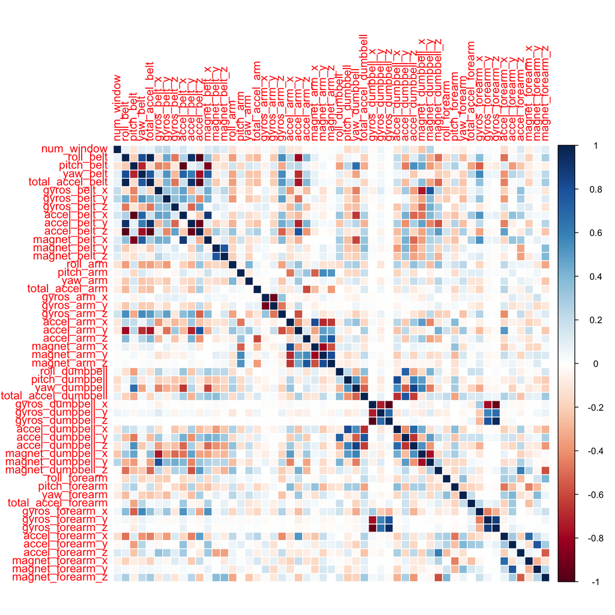

```r
library(corrplot)
corrPlot <- cor(trainData[, -length(names(trainData))])
corrplot(corrPlot, method="color")
```

### Other models

In addition to random forest a boosting model was tried.

```r
set.seed(12345)
controlGbm <- trainControl(method="cv", 5)
modelGbm <- train(classe ~ ., method="gbm", data=trainData, verbose=F, trControl=controlGbm)
modelGbm
```

```
## Stochastic Gradient Boosting
##
## 13737 samples
##    53 predictor
##     5 classes: 'A', 'B', 'C', 'D', 'E'
##
## No pre-processing
## Resampling: Cross-Validated (5 fold)
## Summary of sample sizes: 10989, 10989, 10989, 10990, 10991
## Resampling results across tuning parameters:
##
##   interaction.depth  n.trees  Accuracy   Kappa      Accuracy SD
##   1                   50      0.7612291  0.6970340  0.003777223
##   1                  100      0.8359169  0.7922547  0.003304306
##   1                  150      0.8731163  0.8393934  0.003122909
##   2                   50      0.8838169  0.8528643  0.007281512
##   2                  100      0.9387061  0.9224456  0.008664542
##   2                  150      0.9629472  0.9531140  0.005607514
##   3                   50      0.9297518  0.9110661  0.008984104
##   3                  100      0.9687702  0.9604841  0.004961032
##   3                  150      0.9860232  0.9823192  0.002974451
##   Kappa SD
##   0.004666997
##   0.004140053
##   0.003910646
##   0.009297851
##   0.010962331
##   0.007097037
##   0.011400936
##   0.006285520
##   0.003763805
##
## Tuning parameter 'shrinkage' was held constant at a value of 0.1
##
## Tuning parameter 'n.minobsinnode' was held constant at a value of 10
## Accuracy was used to select the optimal model using  the largest value.
## The final values used for the model were n.trees = 150,
##  interaction.depth = 3, shrinkage = 0.1 and n.minobsinnode = 10.
```

The model has accuracy of 98.5896347% and out of sample error 1.4103653%, which was not as good as the accuracy of the model generated using the random forest algorithm.